# NBA Finals Predictions

Joshua Smith, Cody Boaz, Sean Sabour

May 9, 2016

# Data Acquisition

For our data acquisition we used the NBA api to pull most of our data. A large portion of this project was actually getting data, cleaning it, and exploring the data.

# Data cleaning

After going through many trial and error runs, we noticed that alot of our data wasn’t working with our model because they were factors with levels. We converted these to numeric, deleted any duplicate rows, and changed categorial values into numerical values.

```r
# combining the data frames for teams
cleanData = function(total_teams) {
    x = grep(pattern= "[@]",total_teams$matchup)
    total_teams$away[x] = 1
    total_teams$away[-x] = 0

    total_teams$game_date = sort(as.Date(total_teams$game_date,format = "%b %d, %Y"))
    total_teams$game_id = as.numeric(levels(total_teams$game_id))[total_teams$game_id]
    total_teams$pts = as.numeric(levels(total_teams$pts))[total_teams$pts]
    total_teams$fgm = as.numeric(levels(total_teams$fgm))[total_teams$fgm]
    total_teams$fg3m = as.numeric(levels(total_teams$fg3m))[total_teams$fg3m]
    total_teams$fga = as.numeric(levels(total_teams$fga))[total_teams$fga]
    total_teams$fg3a = as.numeric(levels(total_teams$fg3a))[total_teams$fg3a]
    total_teams$ftm = as.numeric(levels(total_teams$ftm))[total_teams$ftm]
    total_teams$fta = as.numeric(levels(total_teams$fta))[total_teams$fta]
    total_teams$oreb = as.numeric(levels(total_teams$oreb))[total_teams$oreb]
    total_teams$dreb = as.numeric(levels(total_teams$dreb))[total_teams$dreb]
    total_teams$ast = as.numeric(levels(total_teams$ast))[total_teams$ast]
    total_teams$stl = as.numeric(levels(total_teams$stl))[total_teams$stl]
    total_teams$blk = as.numeric(levels(total_teams$blk))[total_teams$blk]
    total_teams$tov = as.numeric(levels(total_teams$tov))[total_teams$tov]
    total_teams$fg_pct = as.numeric(levels(total_teams$fg_pct))[total_teams$fg_pct]
    total_teams$ft_pct = as.numeric(levels(total_teams$ft_pct))[total_teams$ft_pct]
    total_teams$fg3_pct = as.numeric(levels(total_teams$fg3_pct))[total_teams$fg3_pct]
    total_teams$pf = as.numeric(levels(total_teams$pf))[total_teams$pf]
    total_teams$reb = as.numeric(levels(total_teams$reb))[total_teams$reb]
    total_teams$min = as.numeric(levels(total_teams$min))[total_teams$min]
    total_teams$wl = as.character(levels(total_teams$wl))[total_teams$wl]
    total_teams$wl = ifelse(total_teams$wl == "W", 1, 0)
    away = total_teams[total_teams$away == 1,]
    home = total_teams[total_teams$away == 0,]

    #take out dups
    away = away[!duplicated(away$game_id),]
    home = home[!duplicated(home$game_id),]

    home = home[order(home$game_id),]
    away = away[order(away$game_id),]

    home = home[home$game_id %in% away$game_id,]
    away = away[away$game_id %in% home$game_id,]

    total_teams = cbind(home, away)

    names(total_teams) = c( "team_id",   "game_id",   "game_date", "matchup",        "wl",        "min",
     "fgm",       "fga",       "fg_pct",    "fg3m",      "fg3a",      "fg3_pct",
     "ftm",       "fta",       "ft_pct",    "oreb",      "dreb",      "reb",
     "ast",       "stl",       "blk",       "tov",       "pf",        "pts",
     "team_name", "away",      "team_id_opp",   "game_id_opp",   "game_date_opp", "matchup_opp",
     "wl_opp",    "min_opp",   "fgm_opp",   "fga_opp",   "fg_pct_opp", "fg3m_opp",
     "fg3a_opp",  "fg3_pct_opp", "ftm_opp", "fta_opp",    "ft_pct_opp", "oreb_opp",
     "dreb_opp",  "reb_opp",    "ast_opp",  "stl_opp",    "blk_opp",    "tov_opp",
     "pf_opp",    "pts_opp" ,   "team_name_opp", "away_opp")
    return(total_teams)
}
game_by_game14_15 = cleanData(game_by_game14_15)
game_by_game15_16 = cleanData(game_by_game15_16)
```

# Data Exploration

In the graph below, we can see the teams that are top points ranking, like the Golden State Warriors, are also having the highest win percentage. Below that graph we can see the teams that made the NBA Finals and how they are currently doing. Poor Lakers aren’t doing so well this season.

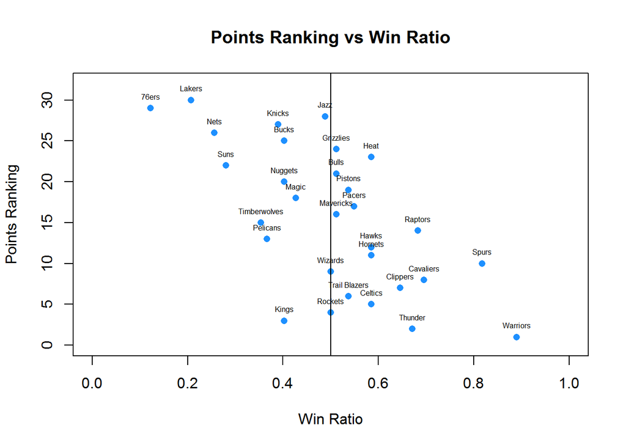

```r
## Plot Points Rank vs Win %
par(mfrow=c(1,1))
plot(team_season_stats15_16$PTS_RANK ~ team_season_stats15_16$WIN_PCT,xlim=c(0,1),ylim=c(0,32),col="dodgerblue",pch=16,xlab="Win Ratio",ylab="Points Ranking",main="Points Ranking vs Win Ratio")
text(team_season_stats15_16$PTS_RANK ~ team_season_stats15_16$WIN_PCT ,labels=team_season_stats15_16$TEAM_NAME, cex= 0.5, pos=3)
abline(v=mean(team_season_stats15_16$WIN_PCT))
```

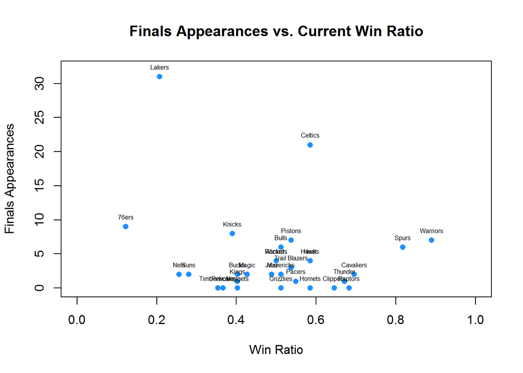

```r
##PLOTS Finals Appearances vs Current Win %
plot(team_season_stats15_16$NBA_FINALS_APPEARANCE ~ team_season_stats15_16$WIN_PCT,xlim=c(0,1),ylim=c(0,32),col="dodgerblue",pch=16,xlab="Win Ratio",ylab="Finals Appearances",main="Finals Appearances vs. Current Win Ratio")
text(team_season_stats15_16$NBA_FINALS_APPEARANCE ~ team_season_stats15_16$WIN_PCT,labels=team_season_stats15_16$TEAM_NAME, cex= 0.5, pos=3)
```

Taking a look at the features fg3_pct, fg3m, and fg3a look related, so does ast and fgm.

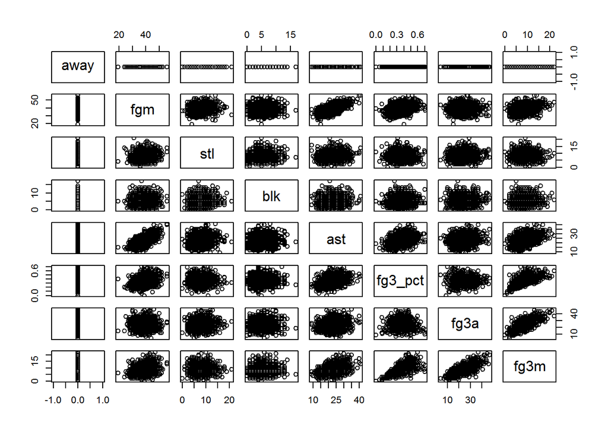

```r
plot(~ away  + fgm + stl + blk + ast + fg3_pct + fg3a + fg3m, data = game_by_game15_16)
```

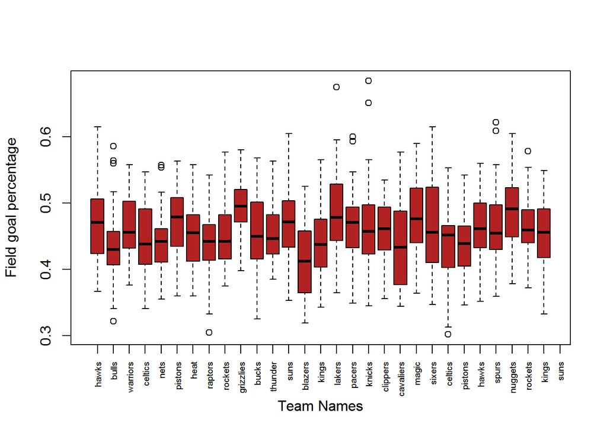

```r
plot(game_by_game15_16$fg_pct ~ game_by_game15_16$team_id, col=c("firebrick"), xaxt='n', xlab="Team Names", ylab="Field goal percentage")
axis(1, at=1:30, labels=game_by_game15_16$team_name[1:30], las=2, cex.axis= 0.6)
```

Looks like the grizzlies have hightest 3 point median. There are some more than 3/2 times the upper quartile outliers with the kings and pacers.

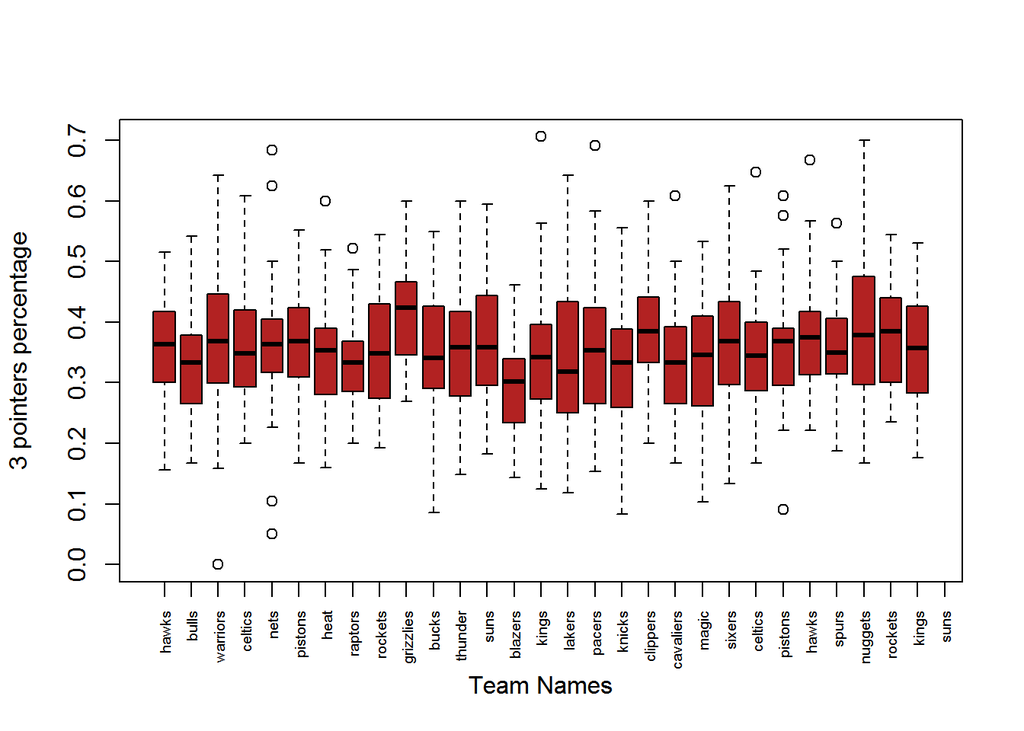

```r
plot(game_by_game15_16$fg3_pct ~ game_by_game15_16$team_id, col=c("firebrick"), xaxt='n', xlab="Team Names", ylab="3 pointers percentage")
axis(1, at=1:30, labels=game_by_game15_16$team_name[1:30], las=2, cex.axis= 0.6)
```

Looks like the Pistons have hightest personal fouls median. There are lot more 3/2 times the upper quartile outliers than lower. I would think that high foul teams would give their opponets an advatage to score more points.

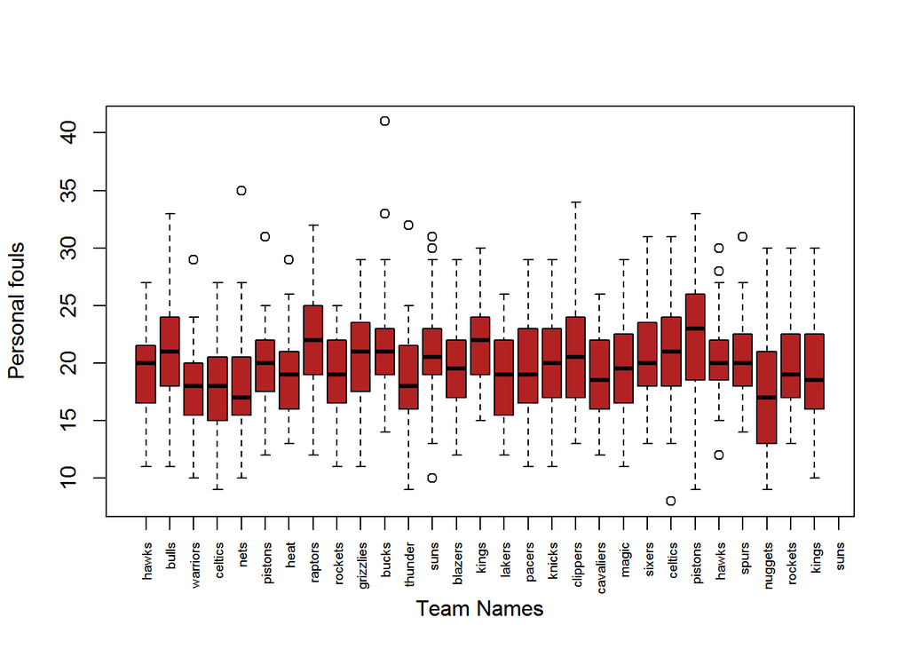

```r
plot(game_by_game15_16$pf ~ game_by_game15_16$team_id, col=c("firebrick"), xaxt='n', xlab="Team Names", ylab="Personal fouls")
axis(1, at=1:30, labels=game_by_game15_16$team_name[1:30], las=2, cex.axis= 0.6)
```

Looks like the Grizzies have hightest total points median. There are lot more 3/2 times the upper quartile outliers than lower.

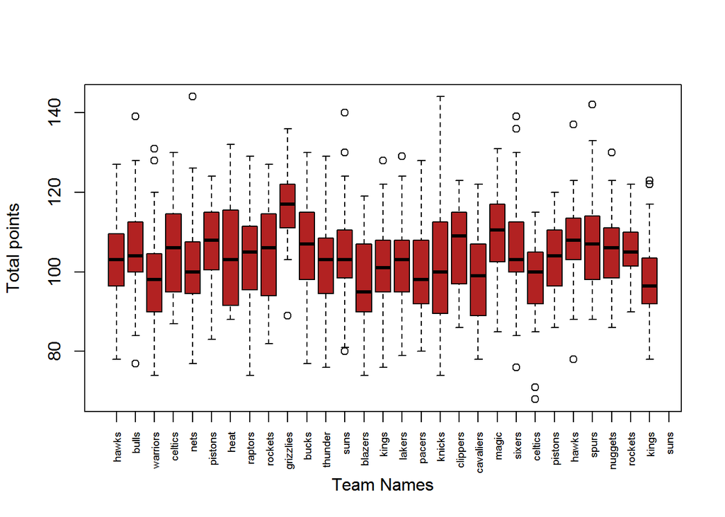

```r
plot(game_by_game15_16$pts ~ game_by_game15_16$team_id, col=c("firebrick"), xaxt='n', xlab="Team Names", ylab="Total points")
axis(1, at=1:30, labels=game_by_game15_16$team_name[1:30], las=2, cex.axis= 0.6)
```

These three plots are the related ones that I stated in the first plot.

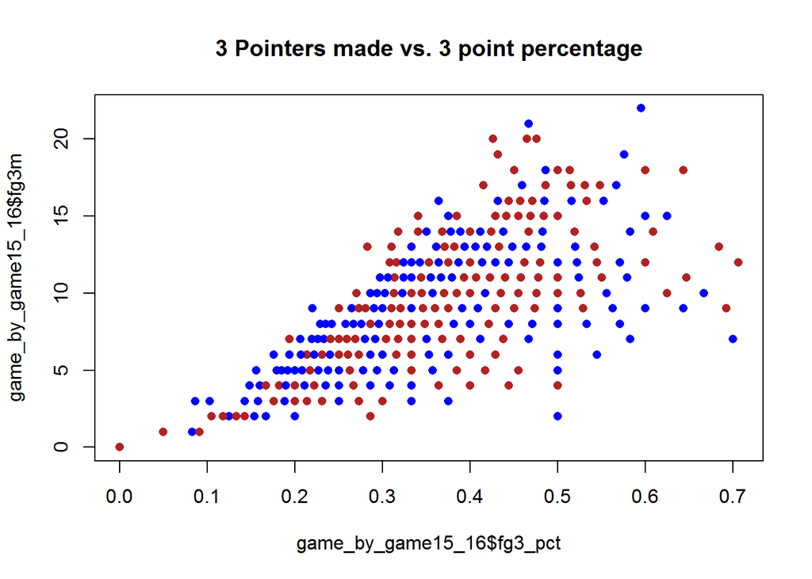

```r
plot(game_by_game15_16$fg3m ~ game_by_game15_16$fg3_pct, col=c("firebrick", "blue"), pch=16, main="3 Pointers made vs. 3 point percentage")
```

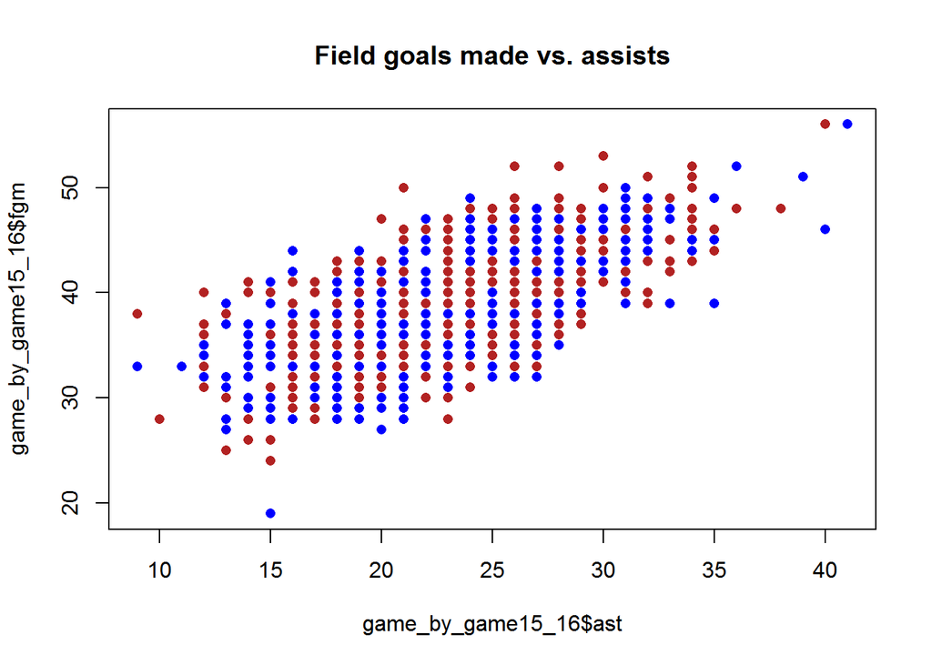

```r
plot(game_by_game15_16$fgm ~ game_by_game15_16$ast, col=c("firebrick", "blue"), pch=16, main="Field goals made vs. assists")
```

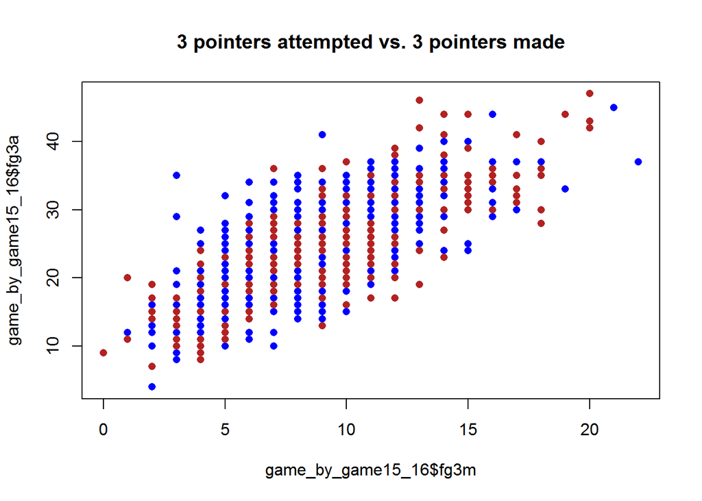

```r
plot(game_by_game15_16$fg3a ~ game_by_game15_16$fg3m, col=c("firebrick", "blue"), pch=16, main="3 pointers attempted vs. 3 pointers made")
```

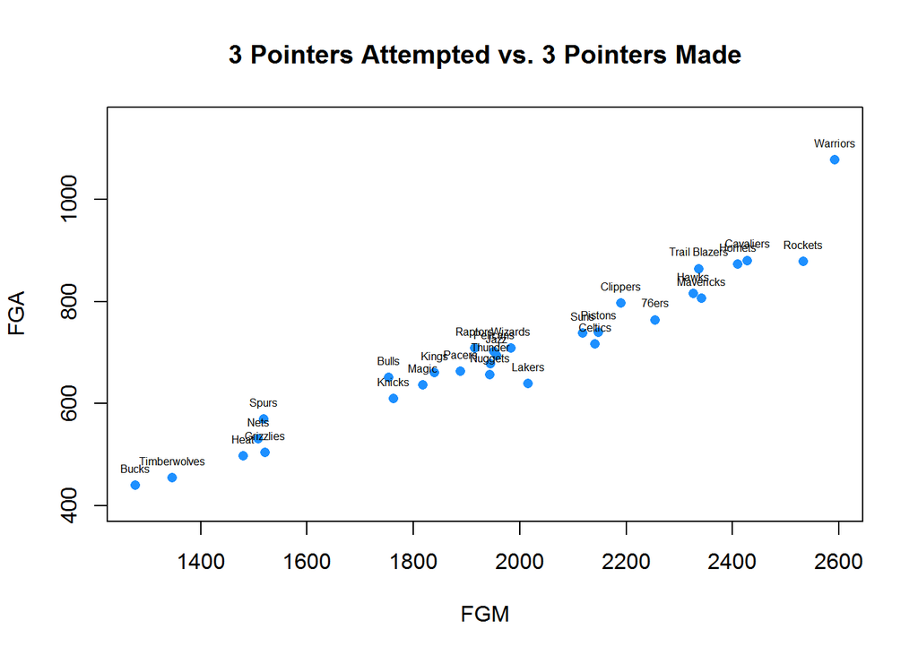

```r
# 3 Pointers Attempted vs 3 Pointers Made KOBEEEE
plot(team_season_stats15_16$FG3M ~ team_season_stats15_16$FG3A, col=c("dodgerblue"),ylim=c(400,1150),main="3 Pointers Attempted vs. 3 Pointers Made",pch=16,xlab="FGM",ylab="FGA")
text(team_season_stats15_16$FG3M ~ team_season_stats15_16$FG3A,labels=team_season_stats15_16$TEAM_NAME, cex= 0.5, pos=3)
```

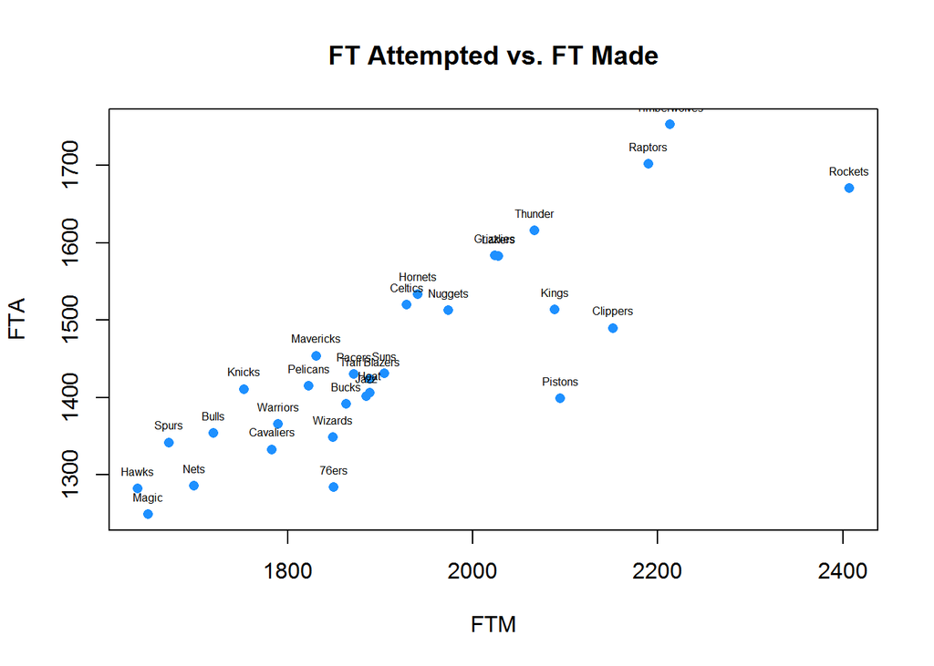

```r
# Free Throws Attempted vs Free Throws Made SHAQ Baby
plot(team_season_stats15_16$FTM ~ team_season_stats15_16$FTA, col=c("dodgerblue"),ylim=c(min(team_season_stats15_16$FTM),max(team_season_stats15_16$FTM)),main="FT Attempted vs. FT Made",pch=16,xlab="FTM",ylab="FTA")
text(team_season_stats15_16$FTM ~ team_season_stats15_16$FTA,labels=team_season_stats15_16$TEAM_NAME, cex= 0.5, pos=3)
```

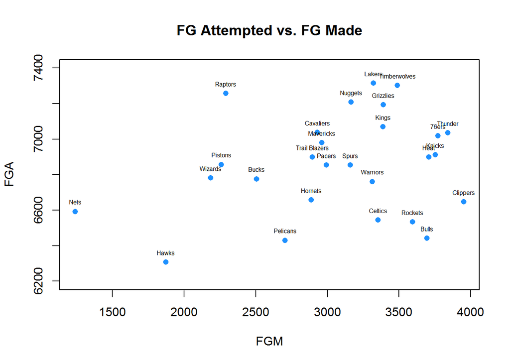

```r
# Field Goals Attempted vs Field Goals Made
plot(team_season_stats15_16$FGA ~ team_season_stats15_16$FGM, col=c("dodgerblue"),ylim=c(6200,7400),main="FG Attempted vs. FG Made",pch=16,xlab="FGM",ylab="FGA")
text(team_season_stats15_16$FGA ~ team_season_stats15_16$FGM,labels=team_season_stats15_16$TEAM_NAME, cex= 0.5, pos=3)
```

# Logistic Regression Model

```r
fit = glm(wl ~  tov + reb + fgm + fg3m + fgm_opp + tov_opp + reb_opp + fg3m_opp, data = game_by_game14_15, family = binomial)
summary(fit)
```

```
##
## Call:
## glm(formula = wl ~ tov + reb + fgm + fg3m + fgm_opp + tov_opp +
##     reb_opp + fg3m_opp, family = binomial, data = game_by_game14_15)
##
## Deviance Residuals:
##     Min       1Q   Median       3Q      Max
## -2.4396  -0.5847   0.1464   0.6060   2.7771
##
## Coefficients:
##             Estimate Std. Error z value Pr(>|z|)
## (Intercept) -1.17063    1.29475  -0.904    0.366
## tov         -0.15386    0.02518  -6.110 9.95e-10 ***
## reb          0.12320    0.01579   7.804 5.98e-15 ***
## fgm          0.25999    0.02379  10.927  < 2e-16 ***
## fg3m         0.21083    0.02904   7.259 3.90e-13 ***
## fgm_opp     -0.26730    0.02378 -11.239  < 2e-16 ***
## tov_opp      0.13841    0.02472   5.599 2.15e-08 ***
## reb_opp     -0.08441    0.01521  -5.550 2.86e-08 ***
## fg3m_opp    -0.18705    0.02878  -6.500 8.02e-11 ***
## ---
## Signif. codes:  0 '***' 0.001 '**' 0.01 '*' 0.05 '.' 0.1 ' ' 1
##
## (Dispersion parameter for binomial family taken to be 1)
##
##     Null deviance: 1569.09  on 1147  degrees of freedom
## Residual deviance:  899.28  on 1139  degrees of freedom
## AIC: 917.28
##
## Number of Fisher Scoring iterations: 6
```

```r
y = predict(fit,newdata = game_by_game15_16,type="response")
predicts = as.numeric(y > 0.6)
actuals = game_by_game15_16$wl

conf_mtx = table(predicts, actuals)

print(conf_mtx)
```

```
##         actuals
## predicts   0   1
##        0 401 130
##        1  67 550
```

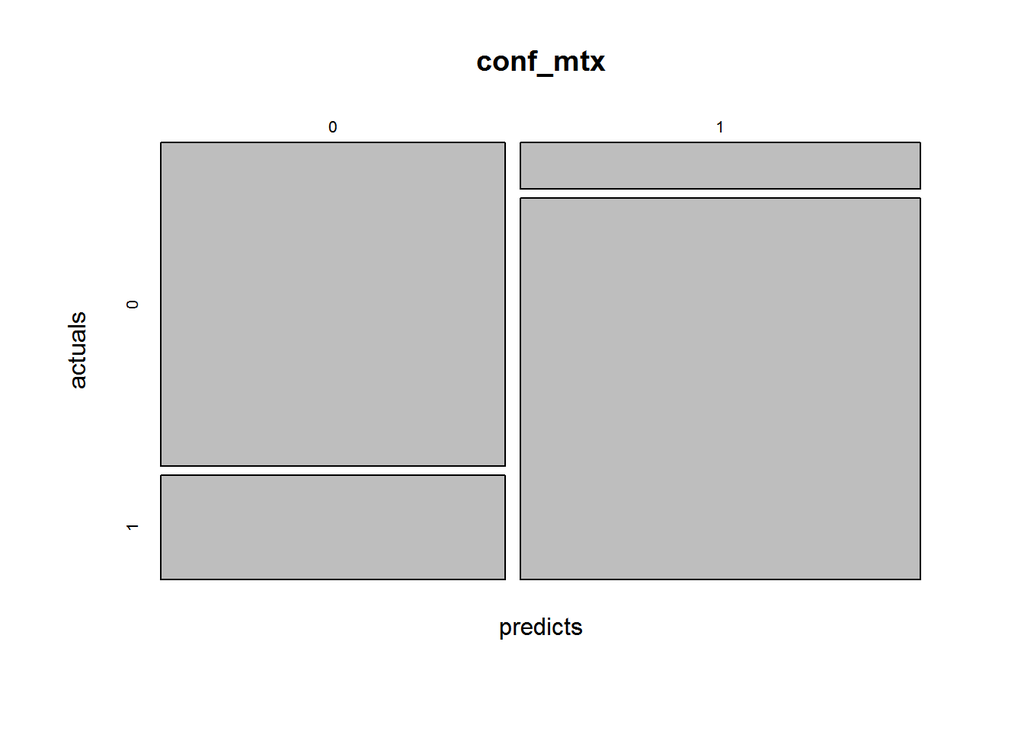

```r
plot(conf_mtx)
```

```r
mean(predicts == actuals)
```

```
## [1] 0.8283972
```

```r
prec_recall_summary = function(predicts, actuals) {
  thresh = seq(0, 1, length.out=50)
  prec_rec = data.frame()
  actuals = factor(as.numeric(actuals))
  for (th in thresh) {
    predicts = factor(as.numeric(y >= th), levels=c("0","1"))
    prec_rec = rbind(prec_rec, as.vector(table(predicts, actuals)))
  }
  names(prec_rec) = c("TN", "FP", "FN", "TP")
  prec_rec$threshold = thresh
  prec_rec$precision = prec_rec$TP/(prec_rec$TP + prec_rec$FP)
  prec_rec$recall    = prec_rec$TP/(prec_rec$TP + prec_rec$FN)
  prec_rec$false_pos = prec_rec$FP/(prec_rec$FP + prec_rec$TN)
  return(prec_rec)
}
```

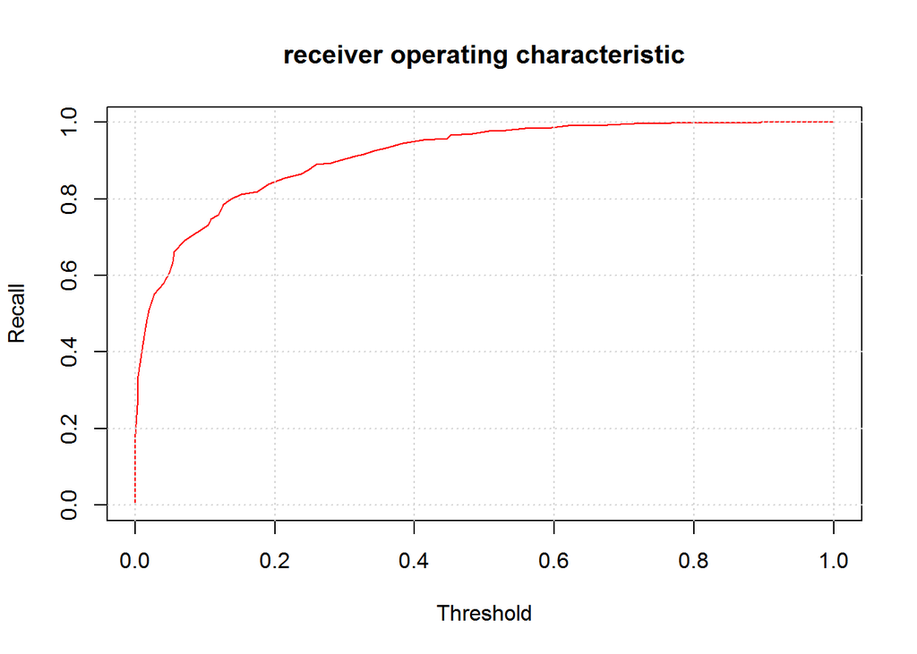

```r
prec_rec1 = prec_recall_summary(predicts, actuals)

par(mfrow=c(1,1))
plot(prec_rec1$recall ~ prec_rec1$false_pos, type = "l", col = "red", xlab="Threshold", ylab="Recall")
grid(nx = NULL, ny = NULL, col = "lightgray", lty = "dotted",
     lwd = par("lwd"), equilogs = TRUE)
title("receiver operating characteristic")
```

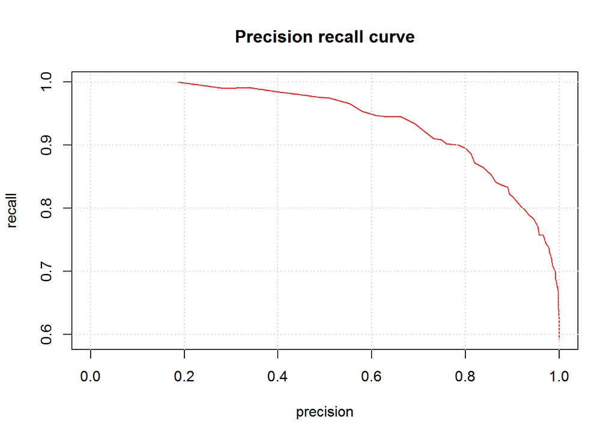

```r
par(mfrow=c(1,1))
plot(prec_rec1$precision ~ prec_rec1$recall, type = "l", col = "red", xlab="precision", ylab="recall")
grid(nx = NULL, ny = NULL, col = "lightgray", lty = "dotted",
     lwd = par("lwd"), equilogs = TRUE)
title("Precision recall curve")
```

The method that we came up with was to take all the games from team 1 and team2 then sort them by date. After sorting by date we are able to get the most recent 30 games. We then sample 10 games out of the 30 to get relevant stats for the teams. Take the mean of those 10 games and give a prediction. We state that if a team has higher than a 60% chance of winning we will call it a win.

```r
head_to_head = function(team1,team2){

  # get both the team's entire season stats
  firstTeam = game_by_game15_16[game_by_game15_16$team_name == team1,]
  firstTeam$game_date = sort(as.Date(firstTeam$game_date,format = "%b %d, %Y"))

  last_10_games_team1 = tail(firstTeam,30)
  last_10_games_team1 = last_10_games_team1[sample(nrow(last_10_games_team1),10), ]
  last_10_games_team1 = lapply(last_10_games_team1[, c("fgm","fg3m","ftm","blk","stl","reb","ast","tov","pf")], mean, na.rm = TRUE)


  secondTeam = game_by_game15_16[game_by_game15_16$team_name_opp == team2,]
  secondTeam$game_date = sort(as.Date(secondTeam$game_date,format = "%b %d, %Y"))
  last_10_games_team2 = tail(secondTeam,30)
  last_10_games_team2 = last_10_games_team2[sample(nrow(last_10_games_team2),10), ]

     last_10_games_team2 = lapply(last_10_games_team2[, c("fgm_opp","fg3m_opp","ftm_opp","blk_opp","stl_opp","reb_opp","ast_opp","tov_opp","pf_opp")], mean, na.rm = TRUE)



  x = as.data.frame(last_10_games_team1)
  y = as.data.frame(last_10_games_team2)
  x = cbind(x,y)

  # Predicts and rounds the scores
  team1_win_loss = predict(fit, newdata = x, type="response")

  team1_win_loss = ifelse(team1_win_loss > 0.6,'W','L')

  return(team1_win_loss)
}
```

The method below simulates a series between two teams. The first two games are at home for team 1, next two are away, then it is alternating until one team reaches 4 wins.

```r
series = function(team1,team2) {
  team1_score = 0
  team2_score = 0

  for(i in 1:7) {
    if(team1_score >= 4 | team2_score >= 4){ break }
    if(i <= 2){
      x = head_to_head(team1,team2)

      if(x == "W"){
        team1_score = team1_score + 1

      }
      else{
        team2_score = team2_score + 1
      }
    } else if(i > 2 && i <=4) {
      x = head_to_head(team2,team1)

      if(x == "W"){
        team2_score = team2_score + 1
      }
      else{
        team1_score = team1_score + 1
      }

    } else if (i == 5){
      x = head_to_head(team1,team2)

      if(x == "W"){
        team1_score = team1_score + 1

      }
      else{
        team2_score = team2_score + 1
      }

    } else if (i == 6) {
      x = head_to_head(team2,team1)

      if(x == "W"){
        team2_score = team2_score + 1
      }
      else{
        team1_score = team1_score + 1
      }

    } else if(i == 7) {
      x = head_to_head(team1,team2)

      if(x == "W"){
        team1_score = team1_score + 1

      }
      else{
        team2_score = team2_score + 1
      }
    }
  }
paste0(team1, ": ", team1_score, ", ",team2, ": ", team2_score)
}
```

This method is a modified version of our original head to head that just takes the last 10 games, returns a percentage of winning the game.

```r
set.seed(12)
head_to_head_2 = function(team1,team2){

  # get both the team's entire season stats
  firstTeam = game_by_game15_16[game_by_game15_16$team_name == team1,]
  firstTeam$game_date = sort(as.Date(firstTeam$game_date,format = "%b %d, %Y"))

  last_10_games_team1 = tail(firstTeam,10)
  last_10_games_team1 = lapply(last_10_games_team1[, c("fgm","fg3m","ftm","blk","stl","reb","ast","tov","pf")], mean, na.rm = TRUE)


  secondTeam = game_by_game15_16[game_by_game15_16$team_name_opp == team2,]
  secondTeam$game_date = sort(as.Date(secondTeam$game_date,format = "%b %d, %Y"))
  last_10_games_team2 = tail(secondTeam,10)
  last_10_games_team2 = lapply(last_10_games_team2[, c("fgm_opp","fg3m_opp","ftm_opp","blk_opp","stl_opp","reb_opp","ast_opp","tov_opp","pf_opp")], mean, na.rm = TRUE)

  x = as.data.frame(last_10_games_team1)
  y = as.data.frame(last_10_games_team2)
  x = cbind(x,y)

  # Predicts and rounds the scores
  team1_win_loss = predict(fit, newdata = x, type="response")

  return(team1_win_loss)
}
```

After getting the percentage from above we are now able to check which team won factoring in probabilities.

```r
game = function(team1,team2){

  team1_home = head_to_head_2(team1,team2)
  x = sample(c(0,1),1,prob=c(team1_home,(1-team1_home)))
  ifelse(x == 0,return (team1), return (team2))
}
```

```r
x = c()
series_2 = function(team1,team2) {
  team1_score = 0
  team2_score = 0

  for(i in 1:7) {
    if(team1_score >= 4 | team2_score >= 4){ break }
    if(i <= 2){
      for(i in 1:100){
        y = game(team1,team2)
        x = c(x,y)
      }
     r = table(x)
     winner = max(row.names(r))

      if(winner == team1){
        team1_score = team1_score + 1
      }
      else{
        team2_score = team2_score + 1
      }
    } else if(i > 2 && i <=4) {
       for(i in 1:100){
        y = game(team2,team1)
        x = c(x,y)
      }
     r = table(x)
     winner = max(row.names(r))

      if(winner == team2){
        team2_score = team2_score + 1
      }
      else{
        team1_score = team1_score + 1
      }

    } else if (i == 5){
      for(i in 1:100){
          y = game(team1,team2)
          x = c(x,y)
        }
       r = table(x)
       winner = max(row.names(r))

      if(winner == team1) {
        team1_score = team1_score + 1

      }
      else{
        team2_score = team2_score + 1
      }

    } else if (i == 6) {
      for(i in 1:100){
        y = game(team2,team1)
        x = c(x,y)
      }
     r = table(x)
     winner = max(row.names(r))

      if(winner == team2){
        team2_score = team2_score + 1
      }
      else{
        team1_score = team1_score + 1
      }

    } else if(i == 7) {
      for(i in 1:100){
            y = game(team1,team2)
            x = c(x,y)
          }
         r = table(x)
         winner = max(row.names(r))

        if(winner == team1) {
        team1_score = team1_score + 1

      }
      else{
        team2_score = team2_score + 1
      }
    }
  }
print(paste0(team1, ": ", team1_score, ", ",team2, ": ", team2_score))
}
```

# 1st Round Predictions for the First model

Winners are:

Blazers Warriors Thunder Spurs Cavaliers Celtics Hornets Pacers

```r
set.seed(12)
series("clippers","blazers")
```

```
## [1] "clippers: 2, blazers: 4"
```

```r
series("warriors","rockets")
```

```
## [1] "warriors: 4, rockets: 0"
```

```r
series("thunder","mavericks")
```

```
## [1] "thunder: 4, mavericks: 0"
```

```r
series("spurs","grizzlies")
```

```
## [1] "spurs: 4, grizzlies: 0"
```

```r
series("cavaliers","pistons")
```

```
## [1] "cavaliers: 4, pistons: 1"
```

```r
series("hawks","celtics")
```

```
## [1] "hawks: 2, celtics: 4"
```

```r
series("heat","hornets")
```

```
## [1] "heat: 1, hornets: 4"
```

```r
series("raptors","pacers")
```

```
## [1] "raptors: 1, pacers: 4"
```

## 1st Round Predictions for the second model

Winners are:

Clippers Warriors Thunder Spurs Pistons Hawks Hornets Raptors

```r
set.seed(12)
series_2("cavaliers","pistons")
```

```
## [1] "cavaliers: 0, pistons: 4"
```

```r
series_2("hawks","celtics")
```

```
## [1] "hawks: 4, celtics: 0"
```

```r
series_2("heat","hornets")
```

```
## [1] "heat: 0, hornets: 4"
```

```r
series_2("raptors","pacers")
```

```
## [1] "raptors: 4, pacers: 0"
```

```r
set.seed(12)
series_2("clippers","blazers")
```

```
## [1] "clippers: 4, blazers: 0"
```

```r
series_2("warriors","rockets")
```

```
## [1] "warriors: 4, rockets: 0"
```

```r
series_2("thunder","mavericks")
```

```
## [1] "thunder: 4, mavericks: 0"
```

```r
series_2("spurs","grizzlies")
```

```
## [1] "spurs: 4, grizzlies: 0"
```

## 2nd Round Predictions for the first model

Winners are:

Warriors Thunder Cavaliers Raptors

```r
set.seed(12)
series("warriors","blazers")
```

```
## [1] "warriors: 4, blazers: 2"
```

```r
series("thunder","spurs")
```

```
## [1] "thunder: 4, spurs: 1"
```

```r
series("cavaliers","hawks")
```

```
## [1] "cavaliers: 4, hawks: 0"
```

```r
series("heat","raptors")
```

```
## [1] "heat: 1, raptors: 4"
```

Winners are:

Warriors Thunder Pistons Hornets

```r
set.seed(12)
series_2("warriors","clippers")
```

```
## [1] "warriors: 4, clippers: 0"
```

```r
series_2("thunder","spurs")
```

```
## [1] "thunder: 4, spurs: 0"
```

```r
series("pistons","hawks")
```

```
## [1] "pistons: 4, hawks: 2"
```

```r
series("hornets","raptors")
```

```
## [1] "hornets: 4, raptors: 2"
```

## 3rd Round Predictions for the first model

Winners are:

Warriors Cavaliers

```r
set.seed(12)
series("warriors","thunder")
```

```
## [1] "warriors: 4, thunder: 1"
```

```r
series("cavaliers","raptors")
```

```
## [1] "cavaliers: 4, raptors: 0"
```

## 3rd Round Predictions for the second model

Winners are:

Warriors Pistons

```r
series_2("warriors","thunder")
```

```
## [1] "warriors: 4, thunder: 0"
```

```r
series_2("pistons","hornets")
```

```
## [1] "pistons: 4, hornets: 0"
```

## Final Round Predictions for the first model

Winner is:

Warriors

```r
set.seed(12)
series("warriors","cavaliers")
```

```
## [1] "warriors: 4, cavaliers: 0"
```

Winner is:

Warriors

```r
set.seed(12)
series_2("warriors","pistons")
```

```
## [1] "warriors: 4, pistons: 0"
```

## Final Thoughts

Thought both models predict the Warriors win the championship, the first model does a better job of predicting closer to what is actually happening in the playoffs.

[Playoff Bracket Click Here](http://www.nba.com/playoffs/)